# QK Box 10.8

Wamelink et al. (2014) compared the growth of 14 species of plant grown in soil collected from near the Rhine River with simulant regolith representing the soil conditions on the moon and on Mars. We will focus on total biomass of *Sedum reflexum* as the response variable. Twenty spatial blocks were established in a glasshouse and for this species, there were 3 small pots (each with five seeds) in each block, representing the three soils types. Soil type is considered a fixed factor and block is a random factor. The full layout of the experiment is shown clearly in Figures 1 and 2 of their paper.

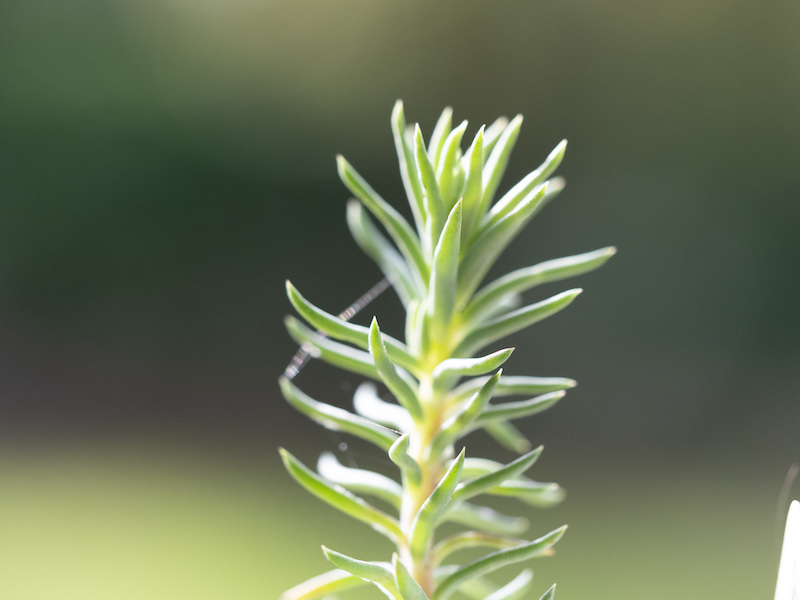

*Sedum*. Mick Keough,

The paper is [here](https://doi.org/10.1371/journal.pone.0103138)

Wamelink, G. W. W., Frissel, J. Y., Krijnen, W. H. J., Verwoert, M. R. & Goedhart, P. W. (2014). Can plants grow on Mars and the Moon: A growth experiment on Mars and Moon soil simulants. *PLoS One*, 9, e103138.

### Preliminaries

First, load the required packages (afex, car, lattice, lme4, lmerTest, nlme, VCA, Rmisc, MuMin)

Import wamelink data file (wamelink1.csv)

```r
wamelink <- read.csv("../data/wamelink1.csv")
head(wamelink,5)
```

|  | block | soil | ngerm | nleaves | nflowers | nalive | totbiomass | abovebiomass | belowbiomass |
| --- | --- | --- | --- | --- | --- | --- | --- | --- | --- |
| 1 | 1 | Moon | 3 | 2 | 0 | 2 | 2.3 | 2.3 | 0.1 |
| 2 | 1 | Earth | 5 | 4 | 0 | 4 | 8.3 | 4.5 | 3.8 |
| 3 | 1 | Mars | 4 | 4 | 0 | 4 | 106.7 | 90.7 | 16.0 |
| 4 | 2 | Moon | 4 | 4 | 0 | 4 | 3.0 | 2.4 | 0.6 |
| 5 | 2 | Mars | 5 | 5 | 0 | 5 | 72.5 | 65.4 | 7.1 |

Set contrasts from afex & make block a factor

```r
set_sum_contrasts()
```

```
## setting contr.sum globally: options(contrasts=c('contr.sum', 'contr.poly'))
```

```r
wamelink$block <- factor(wamelink$block)
```

Check assumptions with boxplots

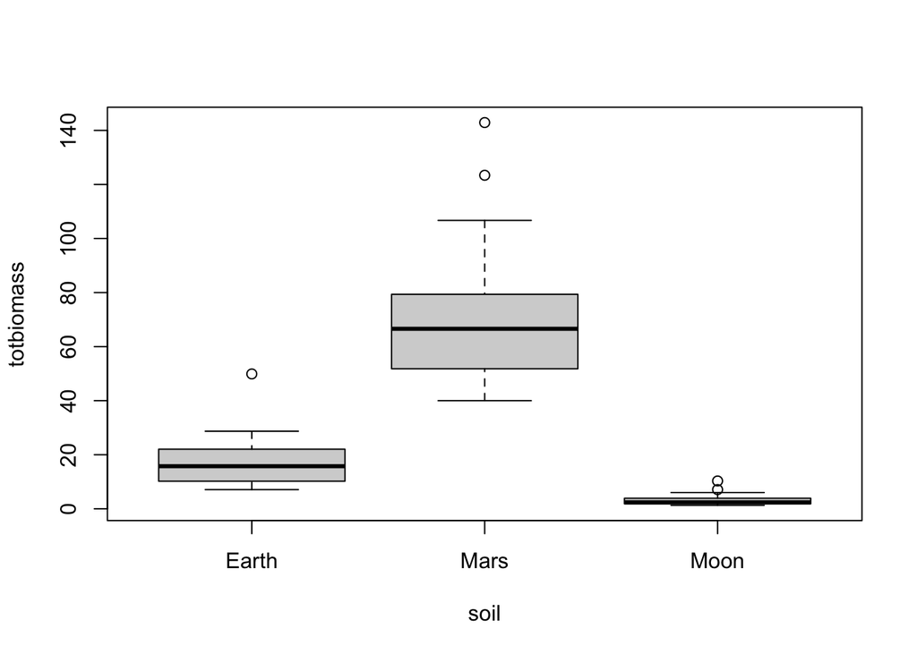

```r
boxplot(totbiomass~soil, data=wamelink)
```

### Fit OLS model with default aov SS

```r
wamelink.aov <- aov(totbiomass~soil+block, data=wamelink)
```

Check residuals - some evidence for interaction

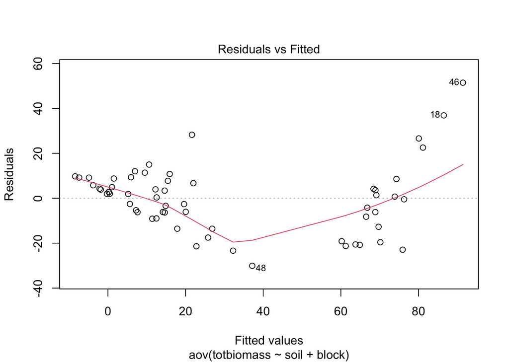

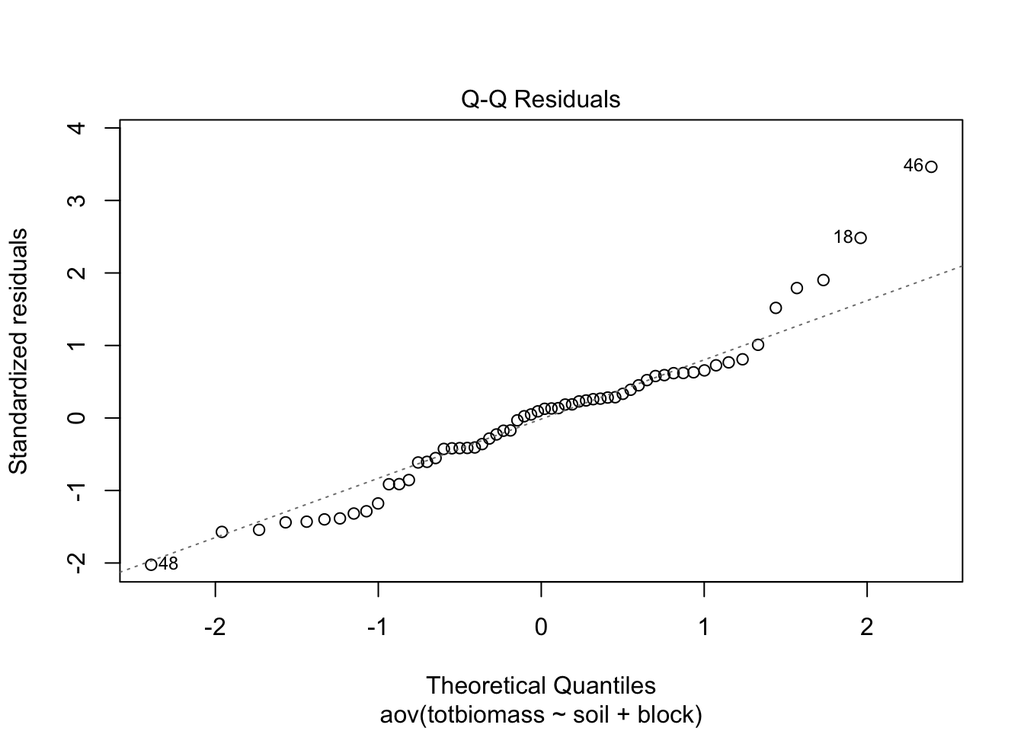

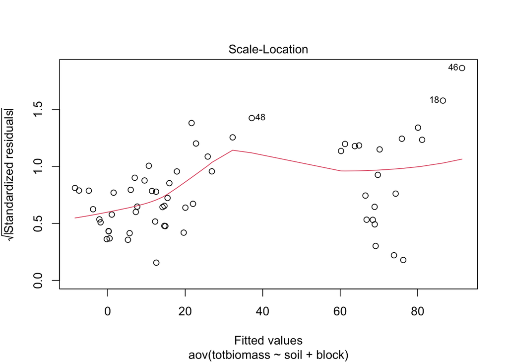

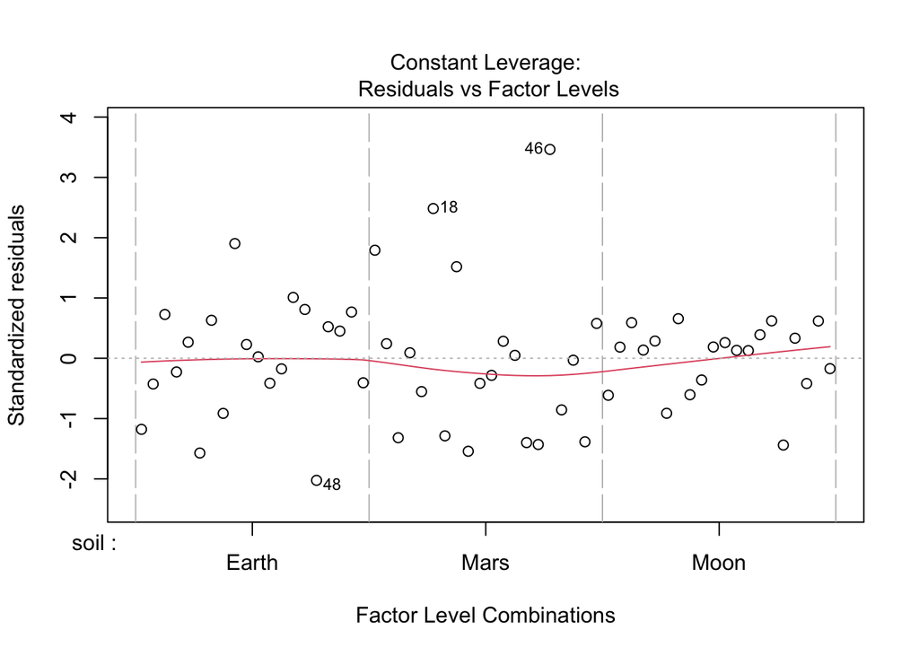

```r
plot(wamelink.aov)
```

Do interaction plot

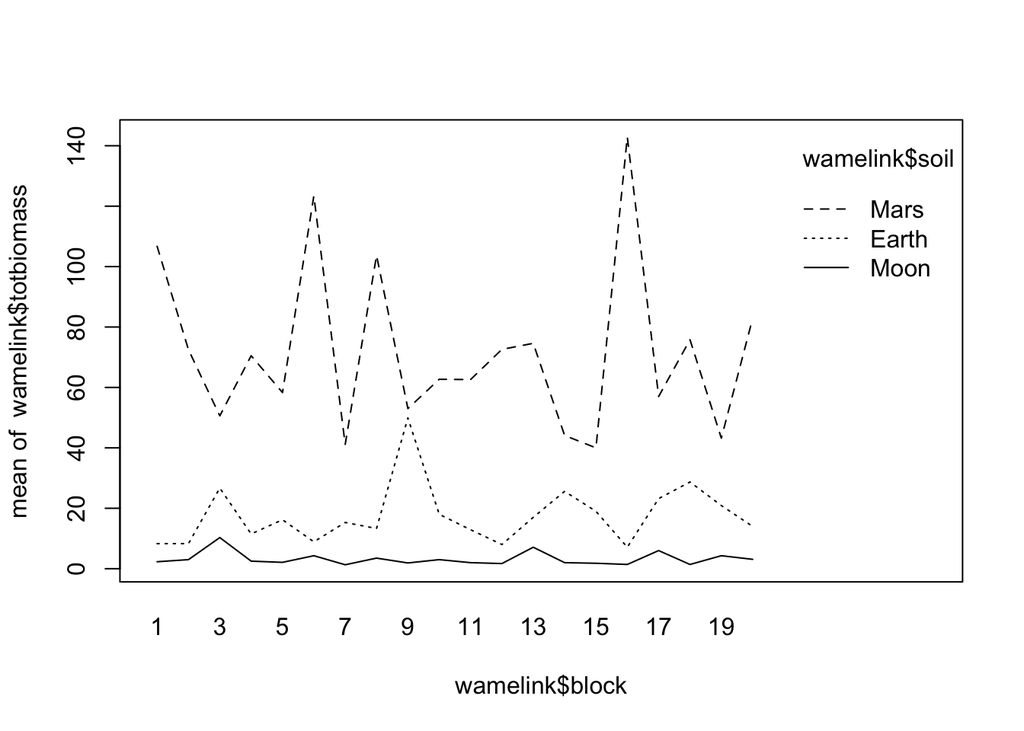

```r
interaction.plot(wamelink$block,wamelink$soil,wamelink$totbiomass)
```

Order of treatments consistent but differences vary greatly between blocks

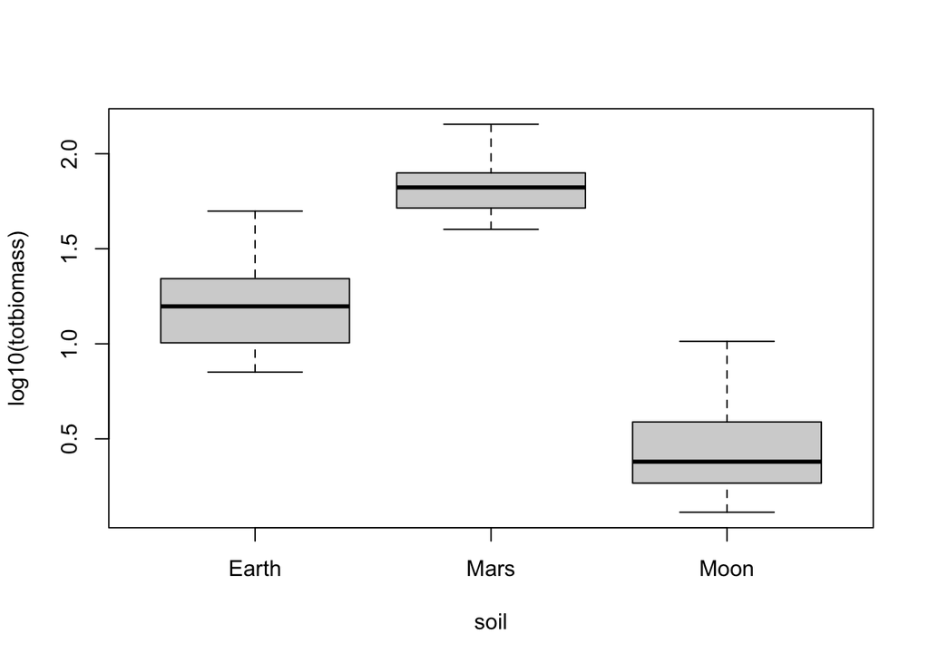

```r
boxplot(log10(totbiomass)~soil, data=wamelink)
```

### Transform to logs due to variance heterogeneity and to minimise interaction

```r
wamelink$ltotbiomass <- log10(wamelink$totbiomass)
```

Recheck diagnostics - much better with less interaction

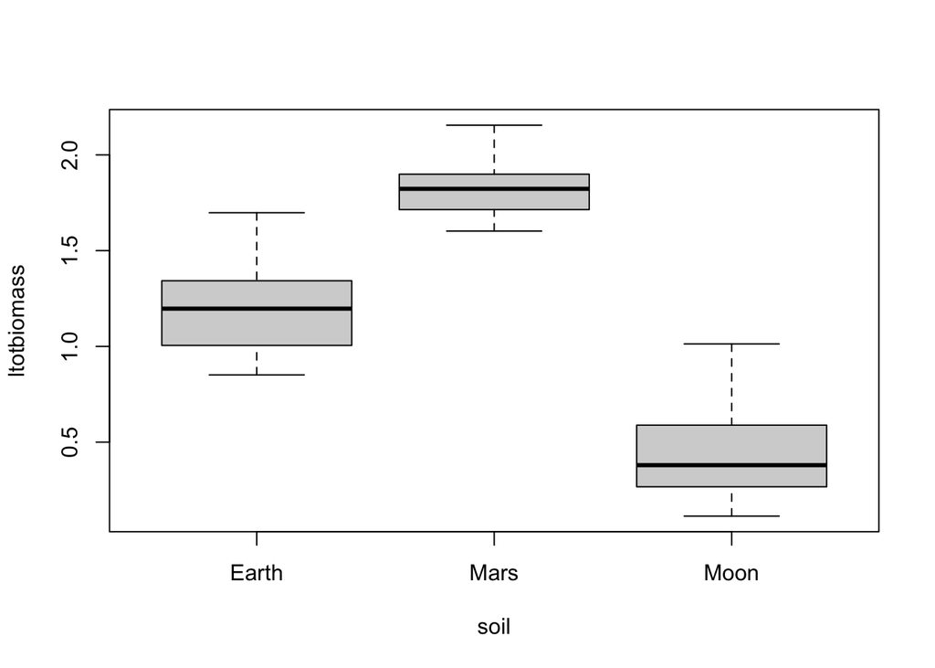

```r
boxplot(ltotbiomass~soil, data=wamelink)
```

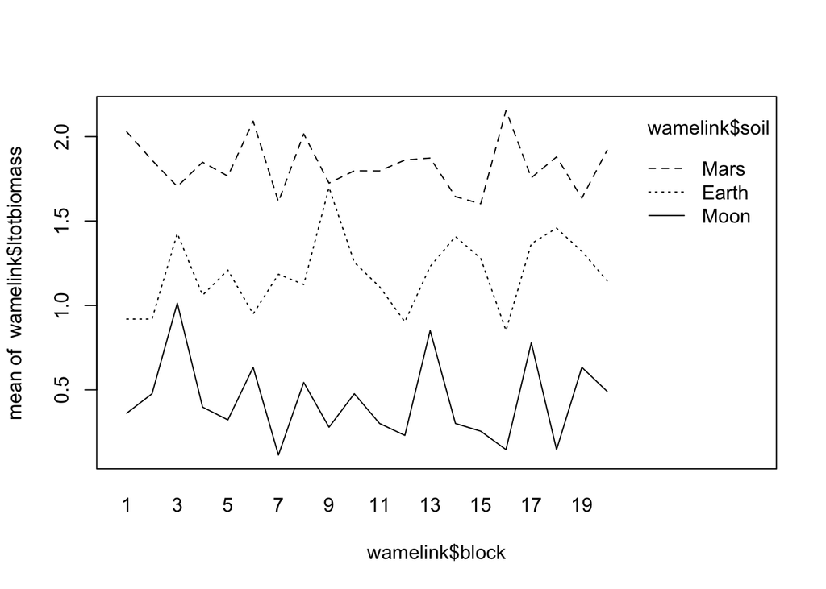

```r
interaction.plot(wamelink$block,wamelink$soil,wamelink$ltotbiomass)
```

### Fit OLS model with default aov SS

```r
wamelink.aov1 <- aov(ltotbiomass~soil+block, data=wamelink)
```

Check residuals - look OK

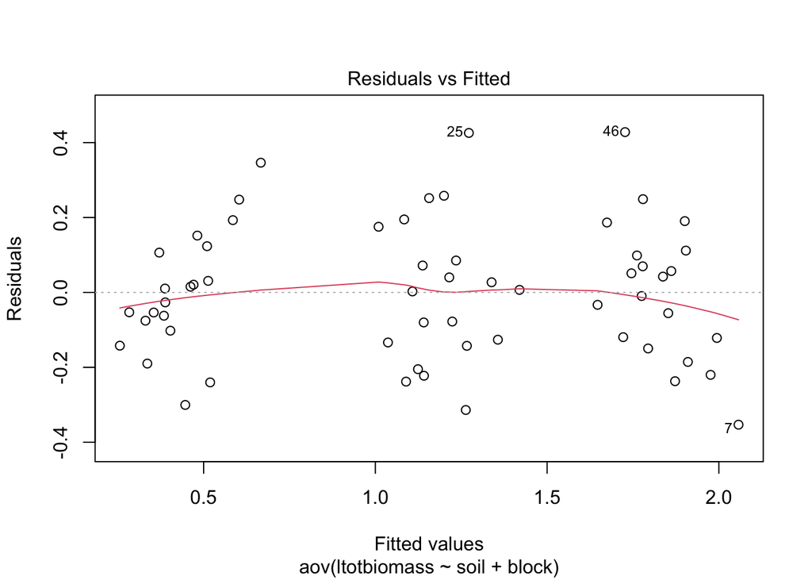

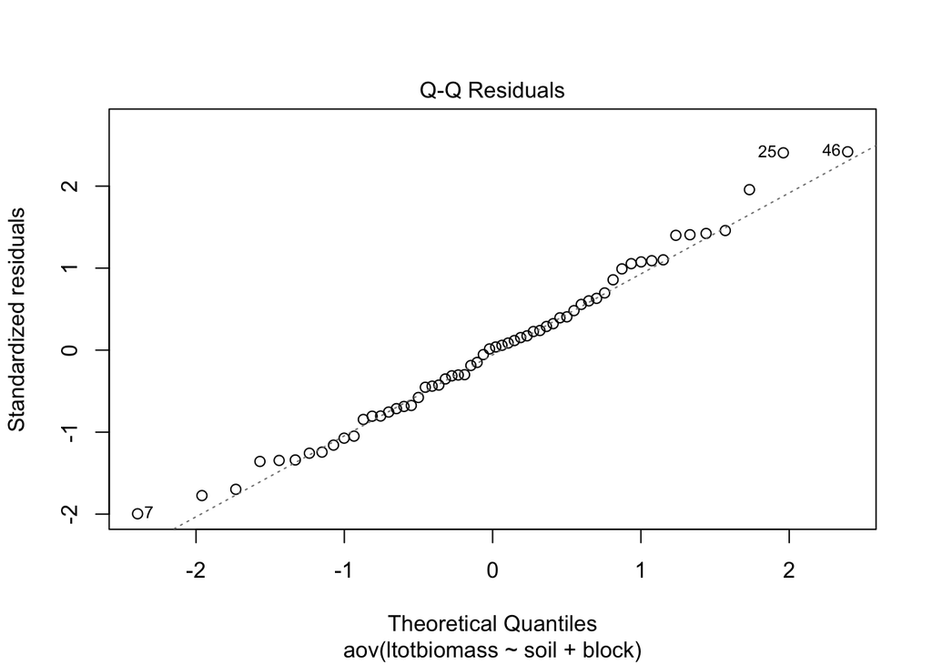

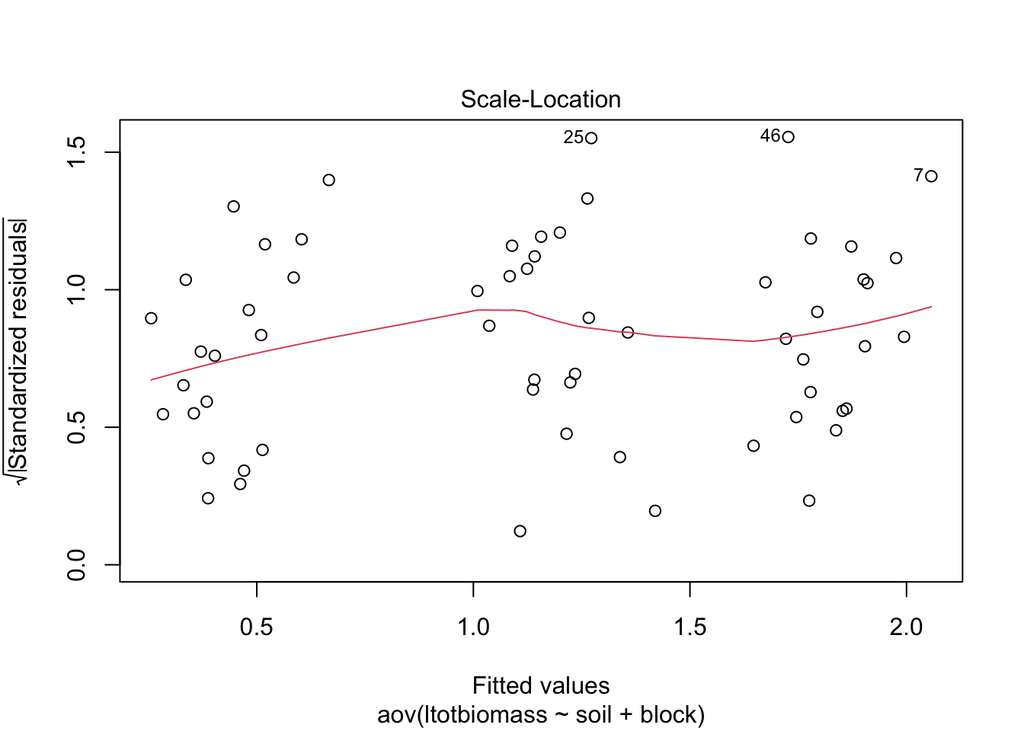

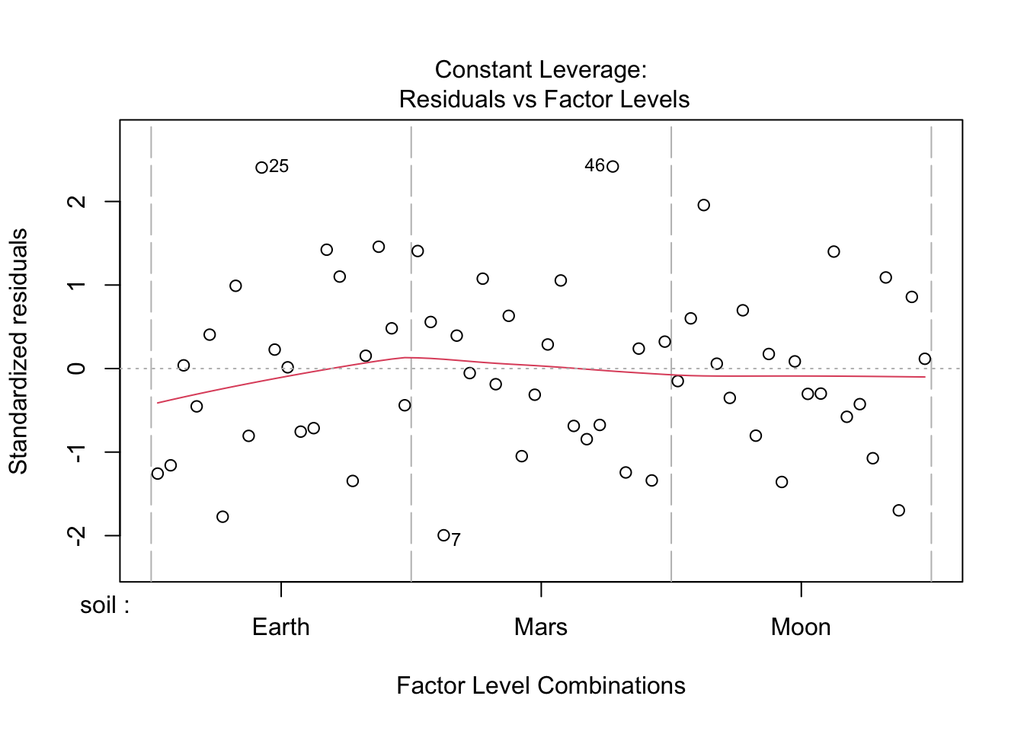

```r
plot(wamelink.aov1)
```

Examine results

```r
options(digits = 3)
summary(wamelink.aov1)
```

```
##             Df Sum Sq Mean Sq F value Pr(>F)
## soil         2  19.39    9.69  196.02 <2e-16 ***
## block       19   0.66    0.03    0.71   0.79
## Residuals   38   1.88    0.05
## ---
## Signif. codes:  0 '***' 0.001 '**' 0.01 '*' 0.05 '.' 0.1 ' ' 1
```

### Use VCA package to get anova var comps

Note that VCs can be -ve when based on OLS model fits

```r
wamelink.vca <- anovaMM(ltotbiomass~soil+(block), wamelink)
```

```
## Convert variable soil from "character" to "factor"!
```

```r
wamelink.vca
```

```
##
##
## ANOVA-Type Estimation of Mixed Model:
## --------------------------------------
##
##  [Fixed Effects]
##
##       int soilEarth  soilMars  soilMoon
##     0.438     0.753     1.391     0.000
##
##
##  [Variance Components]
##
##   Name  DF SS       MS       VC       %Total SD       CV[%]
## 1 total 57                   0.049458 100    0.222391 19.298591
## 2 block 19 0.664948 0.034997 0*       0*     0*       0*
## 3 error 38 1.879389 0.049458 0.049458 100    0.222391 19.298591
##
## Mean: 1.15 (N = 60)
##
## Experimental Design: balanced  |  Method: ANOVA | * VC set to 0 | adapted MS used for total DF
```

```r
VCAinference(wamelink.vca, alpha=0.05, VarVC=TRUE, excludeNeg=FALSE, constrainCI=FALSE)
```

```
##
##
##
## Inference from Mixed Model Fit
## ------------------------------
##
## > VCA Result:
## -------------
##
##  [Fixed Effects]
##
##       int soilEarth  soilMars  soilMoon
##     0.438     0.753     1.391     0.000
##
##
##  [Variance Components]
##
##   Name  DF SS     MS     VC     %Total SD     CV[%]   Var(VC)
## 1 total 57               0.0495 100    0.2224 19.2986 1e-04
## 2 block 19 0.6649 0.035  0*     0*     0*     0*      0
## 3 error 38 1.8794 0.0495 0.0495 100    0.2224 19.2986 1e-04
##
## Mean: 1.15 (N = 60)
##
## Experimental Design: balanced  |  Method: ANOVA | * VC set to 0 | adapted MS used for total DF
##
##
## > VC:
## -----
##       Estimate CI LCL CI UCL One-Sided LCL One-Sided UCL
## total 0.0495   0.0353 0.0741 0.0373        0.0694
## block 0        0*     0.0105 0*            0.0088
## error 0.0495   0.033  0.0821 0.0352        0.0755
##
## > SD:
## -----
##       Estimate CI LCL CI UCL One-Sided LCL One-Sided UCL
## total 0.2224   0.188  0.2723 0.1931        0.2634
## block 0        0*     0.1024 0*            0.0938
## error 0.2224   0.1817 0.2866 0.1876        0.2748
##
## > CV[%]:
## --------
##       Estimate CI LCL  CI UCL  One-Sided LCL One-Sided UCL
## total 19.2986  16.3152 23.6275 16.7546       22.8536
## block 0        0*      8.8866  0*            8.141
## error 19.2986  15.7717 24.8716 16.2822       23.8483
##
##
## 95% Confidence Level  | * CI-limits constrained to be >= 0
## SAS PROC MIXED method used for computing CIs
```

### Fit random intercept model using lme4 and REML

```r
wamelink.lmer1 <- lmer(ltotbiomass~soil + (1|block), REML=TRUE, wamelink)
```

```
## boundary (singular) fit: see help('isSingular')
```

```r
summary(wamelink.lmer1)
```

```
## Linear mixed model fit by REML. t-tests use Satterthwaite's method [
## lmerModLmerTest]
## Formula: ltotbiomass ~ soil + (1 | block)
##    Data: wamelink
##
## REML criterion at convergence: -4.3
##
## Scaled residuals:
##     Min      1Q  Median      3Q     Max
## -1.6076 -0.6731 -0.0887  0.5306  2.7223
##
## Random effects:
##  Groups   Name        Variance Std.Dev.
##  block    (Intercept) 9.83e-26 3.14e-13
##  Residual             4.46e-02 2.11e-01
## Number of obs: 60, groups:  block, 20
##
## Fixed effects:
##             Estimate Std. Error      df t value Pr(>|t|)
## (Intercept)   1.1524     0.0273 57.0000    42.2   <2e-16 ***
## soil1         0.0385     0.0386 57.0000     1.0     0.32
## soil2         0.6762     0.0386 57.0000    17.5   <2e-16 ***
## ---
## Signif. codes:  0 '***' 0.001 '**' 0.01 '*' 0.05 '.' 0.1 ' ' 1
##
## Correlation of Fixed Effects:
##       (Intr) soil1
## soil1  0.000
## soil2  0.000 -0.500
## optimizer (nloptwrap) convergence code: 0 (OK)
## boundary (singular) fit: see help('isSingular')
```

```r
AICc(wamelink.lmer1)
```

```
## [1] 6.83
```

```r
anova(wamelink.lmer1, ddf="Kenward-Roger")
```

|  | Sum Sq | Mean Sq | NumDF | DenDF | F value | Pr(>F) |
| --- | --- | --- | --- | --- | --- | --- |
| soil | 19.4 | 9.69 | 2 | 38 | 217 | 1.6e-21 |

CI on variance components (remembering to square CIs from lmer with are in SD units)

```r
wamelink.ci3 <- confint.merMod(wamelink.lmer1)
```

```
## Computing profile confidence intervals ...
```

```r
wamelink.vc3 <- (wamelink.ci3)^2
print(wamelink.vc3)
```

```
##               2.5 % 97.5 %
## .sig01      0.00000 0.0093
## .sigma      0.03025 0.0620
## (Intercept) 1.20872 1.4528
## soil1       0.00132 0.0129
## soil2       0.36152 0.5641
```

### Fit model that omits blocks

```r
wamelink.gls2 <- gls(ltotbiomass~soil,wamelink)
summary(wamelink.gls2)
```

```
## Generalized least squares fit by REML
##   Model: ltotbiomass ~ soil
##   Data: wamelink
##    AIC  BIC logLik
##   3.72 11.9   2.14
##
## Coefficients:
##             Value Std.Error t-value p-value
## (Intercept) 1.152    0.0273    42.2   0.000
## soil1       0.039    0.0386     1.0   0.322
## soil2       0.676    0.0386    17.5   0.000
##
##  Correlation:
##       (Intr) soil1
## soil1  0.0
## soil2  0.0   -0.5
##
## Standardized residuals:
##     Min      Q1     Med      Q3     Max
## -1.6076 -0.6731 -0.0887  0.5306  2.7223
##
## Residual standard error: 0.211
## Degrees of freedom: 60 total; 57 residual
```

```r
AICc(wamelink.gls2)
```

```
## [1] 4.45
```